# jones_hw2

djones47

2/3/2020

```r
v <- c(8:19) #creating vector v, then printing vector v
v
```

```
##  [1]  8  9 10 11 12 13 14 15 16 17 18 19
```

```r
# 5. creating vector w that is a subset of the first 4 elements of v
w <- c(v[1:4])
w
```

```
## [1]  8  9 10 11
```

6.Make a vector `h` that is a subset of `d`

```r
#creating and printing vector d
d <- c(8:20)
d
```

```
##  [1]  8  9 10 11 12 13 14 15 16 17 18 19 20
```

```r
#6. creating and printing vector h that is a subset of the middle 5 elements of d
h <- c(d[5:9])
h
```

```
## [1] 12 13 14 15 16
```

7.What is the length of vector w?

```r
length(w)
```

```
## [1] 4
```

8. The three properties of a vector are the type, the length and the attributes
9. I predict `c(3,False)` will be a double, `c("a,1)` will be a character, and `c(4L,2)` will also be a double

10: The 4 types of common atomic vectors are character, numeric, integer, and logical. The two uncommon types are complex and raw

11. `1=="1"` is true because I think the character must be coerced into an integer or a double? I think `-1<FALSE` is true because false will become a O and -1<0 is true. `One < 2` is false because I don’t believe R can convert one to 1 so they cannot be truely compared.
12. Maybe NA gets changed to a 0 which would be FALSE which is part of a logical vector?
13. Provide the value of the last element in the result of the vector operation `d*2` from the vectors defined above

```r
#Creating vector e, then determining the last value in e
e <- d*2
e
```

```
##  [1] 16 18 20 22 24 26 28 30 32 34 36 38 40
```

```r
e[13]
```

```
## [1] 40
```

```r
#creating vector a
a <- seq(from = 0.6, to = 1.9, length = 11)
a
```

```
##  [1] 0.60 0.73 0.86 0.99 1.12 1.25 1.38 1.51 1.64 1.77 1.90
```

```r
#creating vector b
b <- which(a >= 1.1)
b
```

```
## [1]  5  6  7  8  9 10 11
```

15.Setting all the elements in vector `a` to 2.0 if they are greater than or equal to 1.1

```r
a[a >= 1.1] <- 2.0
a
```

```
##  [1] 0.60 0.73 0.86 0.99 2.00 2.00 2.00 2.00 2.00 2.00 2.00
```

16. Comparing results of `l` and `j`

```r
# creating l and j
l <- c(list(1,2),c(3,4))
j <- list(list(1,2),c(3,4))

#list l
str(l)
```

```
## List of 4
##  $ : num 1
##  $ : num 2
##  $ : num 3
##  $ : num 4
```

```r
#list j
str(j)
```

```
## List of 2
##  $ :List of 2
##   ..$ : num 1
##   ..$ : num 2
##  $ : num [1:2] 3 4
```

17. using `unlist()` on the previous two vectors

```r
unlist(l)
```

```
## [1] 1 2 3 4
```

```r
unlist(j)
```

```
## [1] 1 2 3 4
```

18. Integers are always ordered, so we use factors because they can be both ordered or unordered.
19. Using `table()`, provide the frequency of no and yes in `my.fac`

```r
# creating my.fac
my.fac <- factor(c("yes","yes","no","yes","yes","yes"))
table(my.fac)
```

```
## my.fac
##  no yes
##   1   5
```

20. `f1` creates a factors of the letters a-z and `levels(f1)` is an object that is just the reverse of the levels of `f1`. `f2` just reverses the order of the factor of letters but not the levels. `f3` reverses the levels of the factor of letters but not the factor itself.
21. If `is.matrix(x)` is true then `is.array(x)` will also be true
22. The two parts of the data frame “kids” and “ages” do not have the same length, so the data frame will not work
23. When using `as.matrix()` on a data set with different types, it coerces the variables into the most flexible type- in this case, character

24.What if we don’t have the same variable names when trying to merge data frames?

```r
#Setting up d1 and d2 data frames
d1 <- data.frame(names = c("Jack", "Jill", "John"), states = c("CA", "IL", "IL"))
d2 <- data.frame(ages = c(10, 7, 12), kids = c("Jill", "Jillian", "Jack"))
d3 <- merge(d1,d2)
d3
```

```
##   names states ages    kids
## 1  Jack     CA   10    Jill
## 2  Jill     IL   10    Jill
## 3  John     IL   10    Jill
## 4  Jack     CA    7 Jillian
## 5  Jill     IL    7 Jillian
## 6  John     IL    7 Jillian
## 7  Jack     CA   12    Jack
## 8  Jill     IL   12    Jack
## 9  John     IL   12    Jack
```

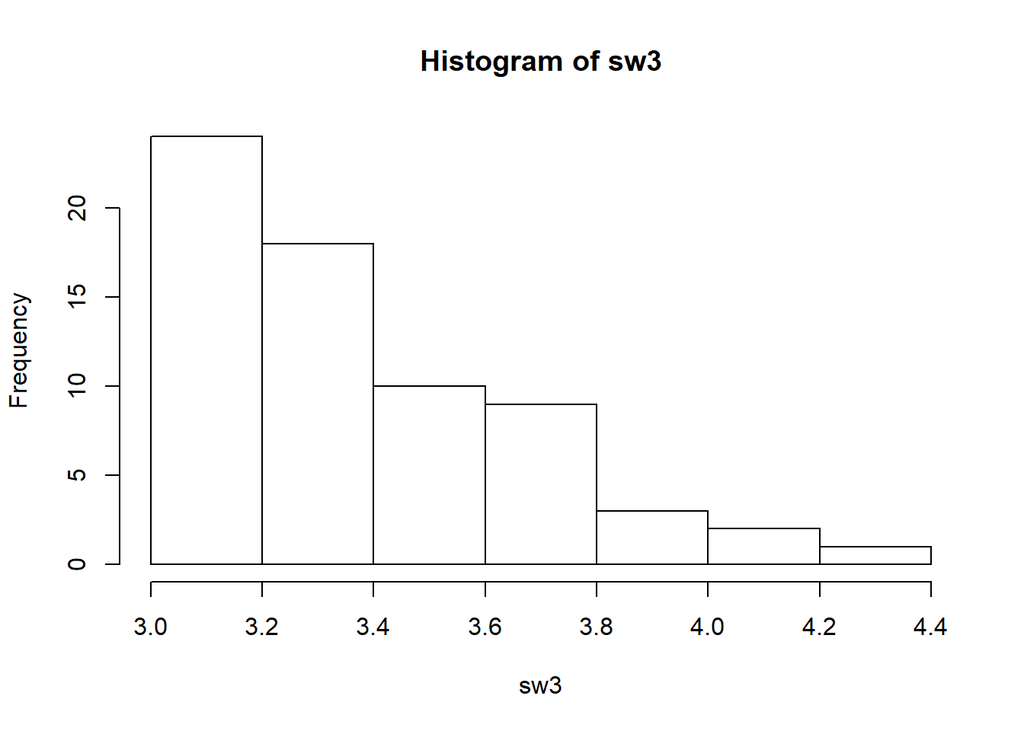

```r
irisdata <- data.frame(iris) #making a separate object that is the data frame (which I now realize I didn't need to do)
sepalwidth <- irisdata$Sepal.Width #Here is a vector that is sepal width
sw3 <- sepalwidth[sepalwidth > 3.0]
hist(sw3)
```

27. Using `apply` on `d` An error happens **Error in apply(d,1,mean): dim(X) must have a positive length**

```r
apply(d,1,mean)
```

```
## Error in apply(d, 1, mean): dim(X) must have a positive length
```

28. The general elements of a function are the name, an argument, and a body of code that does something.
29. If you want to pass a value of an object from the local environment to the global environment, you need to return the object inside of the function.
30. The name of the R function that can help identify errors in a function is `debug()`
32. You can use `stop()` and `stopifnot()` to write our own error messages
33. Keeping your functions short is better because they are easier to manage, update and read and likely to debug.
34. A local variable is one inside of your function and a global variable is one that exists outside of the function. I think it matters which one you use because if you want to use a variable in multiple functions, it is better to have it be global so there is less of a chance of making a mistake by typing the name over or calling it something different etc.
35. You will get an output that says “A wavelength of 10 cm has a frequency of 14989622900 Hz”
36. If you assign the function to `x` as a local object, then if you call `x` outside of the function, nothing will happen.

38.The function for turning wavelenth in micrometers then turning it to gigahertz then using it on 30,000 um

```r
micrometer_to_ghz <- function(micrometer)
{
  #micrometer to meter
  meter <- micrometer/1000000

  #meter to hertz
  hz <- 299792458/meter

  #hertz to gigahertz
  ghz <- hz/1000000000
  ghz


}

micrometer_to_ghz(30000)
```

```
## [1] 9.993082
```

39. The radar band for ~10 ghz is the X band (used for marine radar, weather, ground, surveillance, and synthetic aperture radar)
40. loop for calculating the square of the first 10 elements in the vector x

```r
#Creating vector x
x <- rnorm(40)

#creating the for loop
for(n in x[1:10]) #For every variable in 1-10 of x
{
  square <- n*n #creating object "square" that is the square of the variables
 print (square)

}
```

```
## [1] 0.2197326
## [1] 0.5150045
## [1] 0.004483494
## [1] 0.342074
## [1] 0.4318152
## [1] 0.4691167
## [1] 0.1670435
## [1] 1.238193
## [1] 1.834226
## [1] 0.001559053
```

41. Writing a while loop that prints even numbers from 4 through 29

```r
i <- 3
#while loop
while(i>=2 & i<29) #Setting the boundaries for i
{
  i <- i+1 #making it so i goes to the next number
  if(i %% 2 ==1)next #checking to see if it is even or odd
  print(i) #printing the number

}
```

```
## [1] 4
## [1] 6
## [1] 8
## [1] 10
## [1] 12
## [1] 14
## [1] 16
## [1] 18
## [1] 20
## [1] 22
## [1] 24
## [1] 26
## [1] 28
```

42. Write a while loop that prints multiples of 10 from 100 to 190 **I know I could have done this using the modelo operator in the same way I did the one above, but I wanted to try something different - I also realize I could have created a loop that just multiplied each variable by 10 in a vector from 1 to 19, but that would probably be better in a for loop**

```r
i <- 90 #Setting i=90
while(i>=90 & i<=180) #Restricting the loop
{
  i<-i+10 #Increasing i by 10
  print(i) #Printing i

}
```

```
## [1] 100
## [1] 110
## [1] 120
## [1] 130
## [1] 140
## [1] 150
## [1] 160
## [1] 170
## [1] 180
## [1] 190
```

43.Make a 10x10 matrix of random numbers then write a loop that replaces the 3rd row and 5th column of numbers with “ciao” **Note, I cannot figure out how to turn this back into a matrix or even back into a vector to then put back into a matrix**

```r
matrix100 <- matrix(rnorm(100), ncol=10) #Creating a matrix of 100 random variables
row3 <- matrix100[3,]
column5 <- matrix100[,5]
for (n in row3)
{
  for(n in column5)
  {
    n<-"ciao"

  }
}
```

44. A loop is an automation a certain multi-step process by organizing sequences of actions and grouping the parts that need repetition. An example would be if you had a raster that you wanted to downsample so you could write a loop to downsample each pixel using the average of the pixels surrounding it.

45.To “grow” data using a loop means to update that dataset. An example is shown below

```r
set.seed(42);
m=10; n=10;
mymat<-replicate(m, rnorm(n)) # create matrix of normal random numbers
mydframe=data.frame(mymat)    # transform into data frame
for (i in 1:m) {
  for (j in 1:n) {
    mydframe[i,j]<-mydframe[i,j] + 10*sin(0.75*pi)
    print(mydframe)
  }
}
```

[output not shown]

46. It would be useful to write loops for me to like compare large amounts of water quality data that I have. Maybe I could use it to find the average EC per day over 90 days of 15 increment sampling or something. I think some people look down on loops because they think they can get messy or cumbersome. I guess instead of writing loops you could write other functions that did similar things? I am unsure
47. Use `lapply()` and a function to find the coefficient of variation for all columns in the mtcars dataset

```r
mtcarsdata <- data.frame(mtcars) #Creating an object which I probably don't need to do but it makes me feel better
coeff <- function(x) #Creating a function for the coefficient of variation
{
  p <- sd(x)/mean(x)
  p #unsure if I need to call in this function but I did
}

mtcarscoeff <- lapply(mtcarsdata, FUN = coeff) #using lapply on my data frame
mtcarscoeff
```

```
## $mpg
## [1] 0.2999881
##
## $cyl
## [1] 0.2886338
##
## $disp
## [1] 0.5371779
##
## $hp
## [1] 0.4674077
##
## $drat
## [1] 0.1486638
##
## $wt
## [1] 0.3041285
##
## $qsec
## [1] 0.1001159
##
## $vs
## [1] 1.152037
##
## $am
## [1] 1.228285
##
## $gear
## [1] 0.2000825
##
## $carb
## [1] 0.5742933
```

48. To use that `scale01` function on every column of a data frame, you could use `lapply()`. To apply it to every numeric vector, you could use `sapply()` and set the type to integer or number.
49. TBH I am really confused as to what you are asking in this question- I know I should have gotten to it sooner but I did not and so now I am SOL.
50. Cannot do because I am confused as to what is being asked in 49.